# umiAnalyzer vignette

Stefan Filges

2019-09-12

# Introduction

umiAnalyzer provides tools for analyzing umierrorcorrect output.

## How to make your own umiExperiment object

Define a variable containing the path to the directory with all the umierrorcorrect output folders belonging to your experiment. umiAnalyzer comes with raw test data generated with umierrorcorrect that you can import if you don’t have any of your own.

The UMIexperiment object always maintains your raw data, however you can create as many filters as you like, which will be saved as separate objects to access. You can filter the consensus table of UMIexperiment object with filterUMIobject. The only mandatory arguments are the object to be filtered and a user defined name. You can use that name to retrieve a filtered table using getFilter.

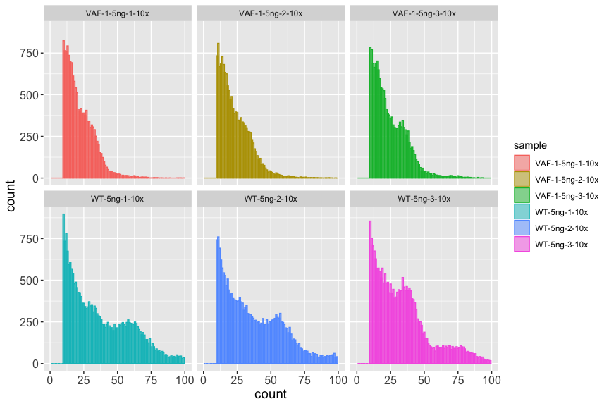

```r
library(umiAnalyzer)

main <- system.file("extdata", package = "umiAnalyzer")

sample.names <- list.dirs(path = main, full.names = FALSE, recursive = FALSE)

simsen <- createUMIexperiment(experiment.name = "test",
                              main.dir = main,
                              dir.names = sample.names)

# save(simsen, file = "data/simsen.RData")

reads <- parseBamFiles(main.dir = main, sample.names = sample.names, cons.depth = 10)

consDepthsPlot(reads)
```

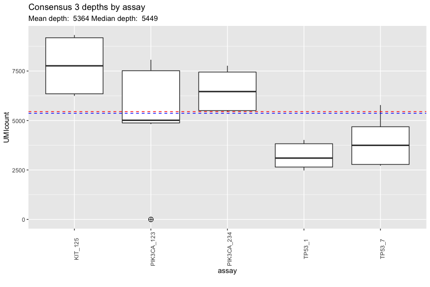

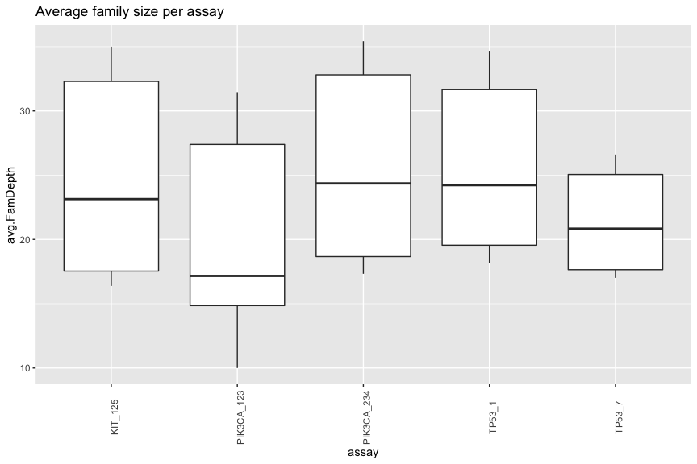

```r
simsen <- generateQCplots(simsen, do.plot = TRUE, group.by = "assay")
```

```r
simsen <- filterUMIobject(
  object = simsen, name = "myfilter", minDepth = 3,
  minCoverage = 100, minFreq = 0, minCount = 0
)

myfilter <- getFilter(object = simsen, name = "myfilter")
myfilter
```

```
#> $myfilter
#> # A tibble: 1,686 x 18
#>    `Sample Name` Contig Position Name  Reference     A     C     G     T
#>    <chr>         <chr>     <dbl> <chr> <chr>     <dbl> <dbl> <dbl> <dbl>
#>  1 VAF-1-5ng-1-… chr17   7673746 TP53… T             0     0     0  2809
#>  2 VAF-1-5ng-1-… chr17   7673747 TP53… C             0  2809     0     0
#>  3 VAF-1-5ng-1-… chr17   7673748 TP53… T             1     0     0  2808
#>  4 VAF-1-5ng-1-… chr17   7673749 TP53… T             0     0     0  2809
#>  5 VAF-1-5ng-1-… chr17   7673750 TP53… G             0     0  2809     0
#>  6 VAF-1-5ng-1-… chr17   7673751 TP53… C             0  2810     0     0
#>  7 VAF-1-5ng-1-… chr17   7673752 TP53… G             0     0  2810     0
#>  8 VAF-1-5ng-1-… chr17   7673753 TP53… G             0     0  2810     0
#>  9 VAF-1-5ng-1-… chr17   7673754 TP53… A          2810     0     0     0
#> 10 VAF-1-5ng-1-… chr17   7673755 TP53… G             0     0  2809     1
#> # … with 1,676 more rows, and 9 more variables: I <dbl>, D <dbl>, N <dbl>,
#> #   Coverage <dbl>, `Consensus group size` <dbl>, `Max Non-ref Allele
#> #   Count` <dbl>, `Max Non-ref Allele Frequency` <dbl>, `Max Non-ref
#> #   Allele` <chr>, sample <chr>
```

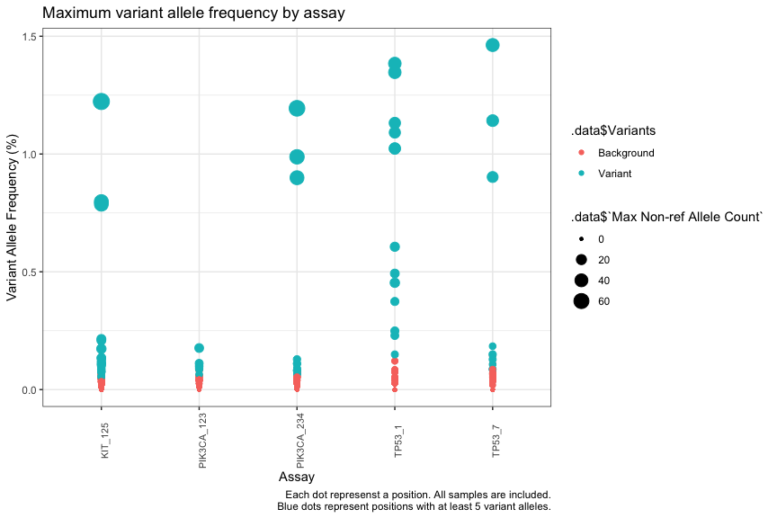

```r
simsen <- generateAmpliconPlots(object = simsen, filter.name = "myfilter", do.plot = TRUE)
```

```r
metaData <- system.file("extdata", "metadata.txt", package = "umiAnalyzer")
simsen <- importDesign(object = simsen, file = metaData)

simsen <- mergeTechnicalReplicates(object = simsen, filter.name = "myfilter")
```

[figure not shown]

[figure not shown]

```r
simsen@merged.data
```

```
#> # A tibble: 562 x 18
#> # Groups:   Name, Contig, Position, Reference [281]
#>    Name  Contig Position Reference replicate avg.A   avg.T   avg.C   avg.G
#>    <chr> <chr>  <fct>    <chr>     <fct>     <dbl>   <dbl>   <dbl>   <dbl>
#>  1 KIT_… chr4   54733142 G         1         0.405 8.06e-1 0.      7.57e+3
#>  2 KIT_… chr4   54733142 G         2         0.825 1.64e+0 2.71e-1 7.57e+3
#>  3 KIT_… chr4   54733143 G         1         1.19  0.      0.      7.58e+3
#>  4 KIT_… chr4   54733143 G         2         1.65  2.81e-1 0.      7.58e+3
#>  5 KIT_… chr4   54733144 T         1         0     7.58e+3 0.      0.
#>  6 KIT_… chr4   54733144 T         2         0     7.58e+3 0.      2.74e-1
#>  7 KIT_… chr4   54733145 C         1         0     0.      7.58e+3 4.02e-1
#>  8 KIT_… chr4   54733145 C         2         0     8.32e-1 7.58e+3 0.
#>  9 KIT_… chr4   54733146 T         1         0     7.58e+3 0.      0.
#> 10 KIT_… chr4   54733146 T         2         0     7.58e+3 0.      0.
#> # … with 552 more rows, and 9 more variables: avg.N <dbl>, avg.I <dbl>,
#> #   avg.D <dbl>, avg.Depth <dbl>, std.Depth <dbl>, avg.Max.AF <dbl>,
#> #   std.MaxAF <dbl>, avg.MaxAC <dbl>, std.MaxAC <dbl>
```

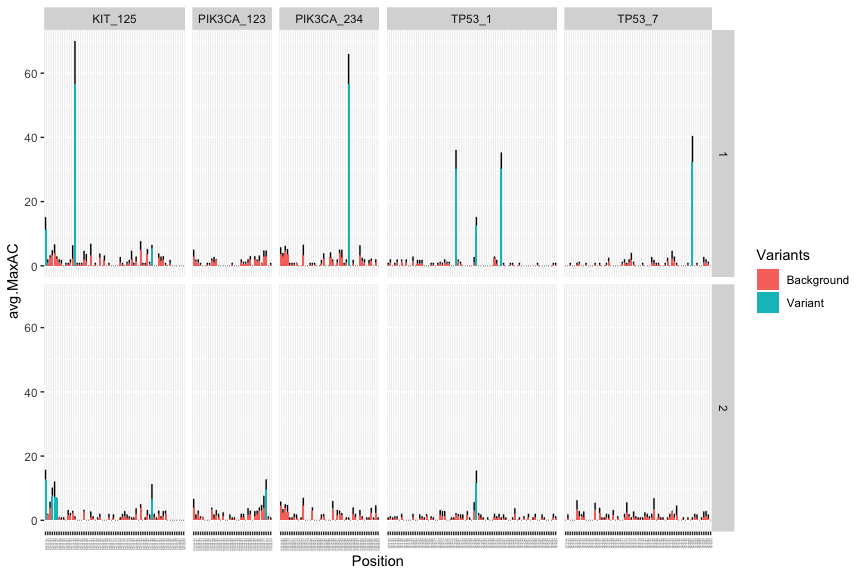

```r
viz_Merged_data(simsen)
```

## Calling variants

umiAnalyzer comes with a build-in umiExperiment object to explore, which was generated using the code above, so it can be used without creating the it first if so desired.

In order to call variants using the umiAnalyzer variant caller simply load the package and test data and use the callVariants function. You can then filter the resulting consensus data (cons.data) within the object, e.g. for significant variants.

```r
data <- simsen
data <- callVariants(data)

data <- filterVariants(object = data, p.adjust = 0.2, minDepth = 5)
```

## Importing experimental designs and statistics

### Experimental design

umiAnalyzer supports adding meta data to a UMIsample or UMIexperiment object, such as experimental design matrices or clinical parameters. This is done using the importDesign function and requires a simple formatted table supplied by the user as a tab separated file. It is important that the order of the samples in the meta data file is the same as when building the UMIexperiment object.

```r
data <- simsen
data <- callVariants(data)

metaData <- system.file("extdata", "metadata.txt", package = "umiAnalyzer")

data <- importDesign(object = data, file = metaData)
```

### Working with meta data

It is also possible to add meta data to an object and to retrieve metadata if needed. The design matrix loaded with importDesign can be retrieved as follows:

```r
design <- getMetaData(object = data, attributeName = "design")

design
```

Similarly, any kind of meta data can be added and retrieved from an object using addMetaData:

```r
comment <- "fix this"
data <- addMetaData(object = data, attributeName = "my-comment", attributeValue = comment)

myattribute <- getMetaData(object = data, attributeName = "my-comment")
myattribute
```